# Séance 1 : Installer la plateforme

Une manchette, des données, et un ordinateur qui sait les lire

Thierry Warin, PhD

HEC Montréal

## Plan · La séance

1. Une manchette à vérifier
2. Le cours : treize séances, trois façons d’apprendre
3. La plateforme : Python, VS Code, l’environnement virtuel
4. Python en vingt minutes
5. Le premier tableau de données
6. Le premier graphique
7. L’IA générative dans ce cours

## À quoi sert la séance 1

### La stratégie

- Transformer une **affirmation** (« Tesla est bonne pour l’environnement ») en **question vérifiable**
- Dire quelles données il faudrait pour y répondre
- Distinguer un fait, une mesure et une interprétation

### Le Python

- Lancer Python dans VS Code, dans un **environnement virtuel**
- Écrire des variables, des listes, des dictionnaires, une fonction
- Lire un fichier CSV avec `pd.read_csv` et afficher ses premières lignes

### La méthode

- Exécuter un script de bout en bout, sans copier-coller dans une console
- Lire un message d’erreur avant de demander de l’aide
- Utiliser l’IA générative pour **expliquer**, jamais pour remplacer la vérification

# Une manchette à vérifier

## « Tesla est vraiment bonne pour l’environnement »

On lit ce genre de phrase tous les jours. Avant de l’accepter ou de la rejeter, un gestionnaire devrait poser **trois questions** :

|  | Question | Ce qu’il faudrait mesurer |
| --- | --- | --- |
| **1** | Bonne *par rapport à quoi* ? | Ford, GM, la moyenne du secteur, un autobus ? |
| **2** | Bonne *selon quelle mesure* ? | Émissions à l’usage, à la fabrication, sur le cycle de vie ? |
| **3** | Bonne *pour qui, et où* ? | Le mix électrique du Québec n’est pas celui de la Pologne |

Une donnée ne répond jamais à une manchette. Elle répond à une **question précise**, que la manchette ne pose pas. Le travail de l’analyste commence par l’écrire.

## Deux autres manchettes, pour la suite du cours

> « L’Amérique crée plus de valeur que tout autre pays. »

> « Les entreprises qui investissent en R-D sont plus rentables. »

D’ici la séance 6, vous aurez les outils pour **importer** les données qui permettent de les tester, les **manipuler**, les **représenter** et les **tester statistiquement**.

Les séances 7 à 11, données par mes collègues, reprendront ces questions à partir d’articles de recherche et de cas (Harvard, Ivey) : fusions-acquisitions, ESG, groupes stratégiques, rémunération des dirigeants.

# Le cours

## Treize séances, trois façons d’apprendre

| Séances | Qui | Comment |
| --- | --- | --- |
| **1 à 6** | Thierry Warin | Python sur des données réelles : installer, manipuler, importer, représenter, tester |
| **7 à 11** | Marie-Ann et Russell | Articles de recherche et études de cas ; coaching des projets |
| **12 et 13** | L’équipe | Présentations individuelles |

Chaque séance a **trois temps**, toujours dans le même ordre :

|  | Quand | Quoi |
| --- | --- | --- |
| **Pré-séance** | Avant le cours | Lecture, installation, données, autovérification |
| **Cours** | ~90 min | Les concepts et le code, démontrés en direct |
| **Pratique** | ~90 min | Vous écrivez le code, sur une question de stratégie |

## L’évaluation

[output not shown]

Le projet final demande **un fichier de code Python** qui reproduit vos tableaux et vos graphiques. Les séances 1 à 6 existent pour que ce fichier soit le vôtre.

# La plateforme

## Quatre pièces, et ce que fait chacune

| Pièce | Ce que c’est | Analogie |
| --- | --- | --- |
| **Python** | Le langage, et l’*interpréteur* qui exécute le code | Le moteur |
| **Les paquets** (`pandas`, `matplotlib`…) | Du code écrit par d’autres, que l’on importe | Les outils dans le coffre |
| **L’environnement virtuel** (`.venv`) | Une copie de Python propre à **ce** projet, avec **ses** paquets | Un coffre par chantier |
| **VS Code** | L’éditeur où l’on écrit et exécute le code | Le tableau de bord |

```
MNGT60439/                  ← ouvrez CE dossier dans VS Code (Fichier → Ouvrir le dossier)
├── .venv/                  ← l'environnement virtuel (créé à la pré-séance)
├── data/                   ← les données du cours
│   ├── entreprises.csv
│   ├── pays.csv
│   └── strategie.db
├── 01-installer-la-plateforme/
└── requirements.txt        ← la liste des paquets
```

## Pourquoi un environnement virtuel ?

Sans lui, tous vos projets partagent les mêmes paquets. Le jour où un projet exige `pandas 2.2` et un autre `pandas 3.0`, l’un des deux casse — souvent la veille d’une remise.

```bash
python -m venv .venv                    # créer (une seule fois)
source .venv/bin/activate               # activer — macOS / Linux
.venv\Scripts\activate                  # activer — Windows
python -m pip install -r requirements.txt   # installer les paquets du cours
```

Dans VS Code : `Ctrl/Cmd + Maj + P` → **Python: Select Interpreter** → choisissez celui qui contient `.venv`. Le nom apparaît en bas à droite de la fenêtre. S’il n’y est pas, vos `import` échoueront.

## Script ou notebook ?

|  | Script `.py` | Notebook `.ipynb` |
| --- | --- | --- |
| Exécution | De haut en bas, en entier | Cellule par cellule, dans n’importe quel ordre |
| Force | Reproductible : même entrée, même sortie | Exploratoire : on voit le résultat sous le code |
| Piège | Il faut tout relancer pour voir un résultat | Une cellule exécutée hors d’ordre ment |

Dans ce cours, **on explore en notebook ou avec `# %%`, on remet un script**. Dans VS Code, une ligne `# %%` découpe un script en cellules exécutables avec `Maj + Entrée` : on a les deux.

# Python en vingt minutes

## Des nombres et des variables

```python
chiffre_affaires = 96_773      # Tesla, 2023, en millions de $ US
resultat_net = 14_974

marge_nette = resultat_net / chiffre_affaires
print(marge_nette)
print(f"Marge nette de Tesla en 2023 : {marge_nette:.1%}")
```

```
0.1547332417099811
Marge nette de Tesla en 2023 : 15.5%
```

- Le signe `=` **range** une valeur dans un nom ; il ne dit pas que deux choses sont égales.
- Le `_` dans `96_773` est permis et ne change rien : il aide à lire.
- La chaîne `f"..."` insère des valeurs ; `:.1%` affiche en pourcentage à une décimale.

## Les types : ce que Python croit que vous lui donnez

```python
annee = 2023                 # int   : un entier
marge = 0.155                # float : un nombre à virgule
entreprise = "Tesla"         # str   : du texte
est_rentable = marge > 0     # bool  : vrai ou faux

print(type(annee), type(marge), type(entreprise), type(est_rentable))
print("2023" + "1", 2023 + 1)
```

```
<class 'int'> <class 'float'> <class 'str'> <class 'bool'>
20231 2024
```

`"2023" + "1"` donne `"20231"`. Un chiffre lu comme du texte est **l’erreur la plus fréquente** lorsqu’on importe des données ; on la retrouvera à la séance 3.

## Listes et dictionnaires

```python
constructeurs = ["Tesla", "Ford", "General Motors"]       # une liste : un ordre
print(constructeurs[0], len(constructeurs))               # Python compte à partir de 0

ventes_2023 = {"Tesla": 96_773, "Ford": 176_191, "General Motors": 157_658}   # clé → valeur
print(ventes_2023["Ford"])

for nom in constructeurs:
    print(f"{nom:15s} {ventes_2023[nom]:>9,} M$")
```

```
Tesla 3
176191
Tesla              96,773 M$
Ford              176,191 M$
General Motors    157,658 M$
```

Un **dictionnaire de listes** a déjà la forme d’un tableau : chaque clé est une colonne.

## Une fonction : écrire une fois, utiliser partout

```python
def marge(resultat, ventes):
    """Marge nette : la part de chaque dollar de ventes qui reste en profit."""
    return resultat / ventes

print(f"{marge(14_974, 96_773):.1%}")   # Tesla
print(f"{marge(4_347, 176_191):.1%}")   # Ford
```

```
15.5%
2.5%
```

Si vous copiez-collez le même calcul trois fois, écrivez une fonction. Si la formule change, vous la corrigez à un seul endroit.

## Importer un paquet

```python
import pandas as pd          # les tableaux de données — le cœur du cours
import numpy as np           # le calcul numérique
import matplotlib.pyplot as plt   # les graphiques

print(pd.__version__)
```

```
3.1.1
```

`as pd` est une convention, pas une obligation — mais tout le monde l’utilise, et toutes les réponses que vous trouverez en ligne (ou que l’IA vous donnera) la supposent.

# Le premier tableau de données

## D’un dictionnaire à un DataFrame

```python
df = pd.DataFrame({
    "entreprise": ["Tesla", "Ford", "General Motors"],
    "ventes":     [96_773, 176_191, 157_658],
    "resultat":   [14_974, 4_347, 9_840],
})
df["marge"] = df["resultat"] / df["ventes"]
df
```

|  | entreprise | ventes | resultat | marge |
| --- | --- | --- | --- | --- |
| 0 | Tesla | 96773 | 14974 | 0.154733 |
| 1 | Ford | 176191 | 4347 | 0.024672 |
| 2 | General Motors | 157658 | 9840 | 0.062414 |

Un **DataFrame** est un tableau : des lignes (les observations) et des colonnes (les variables). Une opération sur une colonne s’applique à **toutes** les lignes d’un coup.

## Les vraies données : `data/entreprises.csv`

```python
entreprises = pd.read_csv("data/entreprises.csv")
print(entreprises.shape)
entreprises.head()
```

```
(480, 12)
```

|  | ticker | entreprise | cik | secteur | pays_siege | annee | chiffre_affaires | resultat_net | actifs_totaux | capitaux_propres | rd | investissements |
| --- | --- | --- | --- | --- | --- | --- | --- | --- | --- | --- | --- | --- |
| 0 | TSLA | Tesla | 1318605 | Automobile | USA | 2010 | 116.7 | -154.3 | 386.1 | 207.0 | 93.0 | 40.2 |
| 1 | TSLA | Tesla | 1318605 | Automobile | USA | 2011 | 204.2 | -254.4 | 713.4 | 224.0 | 209.0 | 184.2 |
| 2 | TSLA | Tesla | 1318605 | Automobile | USA | 2012 | 413.3 | -396.2 | 1114.2 | 124.7 | 274.0 | 239.2 |
| 3 | TSLA | Tesla | 1318605 | Automobile | USA | 2013 | 2013.5 | -74.0 | 2416.9 | 667.1 | 232.0 | 264.2 |
| 4 | TSLA | Tesla | 1318605 | Automobile | USA | 2014 | 3198.4 | -294.0 | 5830.7 | 911.7 | 464.7 | 969.9 |

32 grandes entreprises cotées aux États-Unis, exercices 2010 à 2024, tirées des états financiers déposés à la **SEC** (montants en millions de dollars US).

## Ce qu’il y a dedans

```python
entreprises.info()
```

```
<class 'pandas.DataFrame'>
RangeIndex: 480 entries, 0 to 479
Data columns (total 12 columns):
 #   Column            Non-Null Count  Dtype
---  ------            --------------  -----
 0   ticker            480 non-null    str
 1   entreprise        480 non-null    str
 2   cik               480 non-null    int64
 3   secteur           480 non-null    str
 4   pays_siege        480 non-null    str
 5   annee             480 non-null    int64
 6   chiffre_affaires  477 non-null    float64
 7   resultat_net      469 non-null    float64
 8   actifs_totaux     475 non-null    float64
 9   capitaux_propres  477 non-null    float64
 10  rd                345 non-null    float64
 11  investissements   359 non-null    float64
dtypes: float64(6), int64(2), str(4)
memory usage: 58.2 KB
```

`rd` manque pour un quart des lignes : Amazon, Walmart ou Coca-Cola ne publient pas de ligne « recherche et développement ». Une donnée manquante est souvent une **information**, pas un accident. Nous y reviendrons à la séance 2.

## Une question, une ligne de code

*Quel constructeur automobile était le plus rentable en 2023 ?*

```python
auto = entreprises[(entreprises["secteur"] == "Automobile") & (entreprises["annee"] == 2023)]
auto = auto.assign(marge=auto["resultat_net"] / auto["chiffre_affaires"])
auto[["entreprise", "chiffre_affaires", "resultat_net", "marge"]].sort_values("marge", ascending=False)
```

|  | entreprise | chiffre_affaires | resultat_net | marge |
| --- | --- | --- | --- | --- |
| 13 | Tesla | 96773.0 | 14974.0 | 0.154733 |
| 43 | General Motors | 157658.0 | 9840.0 | 0.062414 |
| 28 | Ford | 176191.0 | 4347.0 | 0.024672 |

Tesla vend **près de deux fois moins** que Ford, mais garde **six fois plus** de chaque dollar de ventes (15,5 % contre 2,5 %). Est-ce que cela dit quelque chose de l’environnement ? **Non** — et c’est exactement la discipline du cours.

# Le premier graphique

## Tesla, Ford, GM : quinze ans de ventes

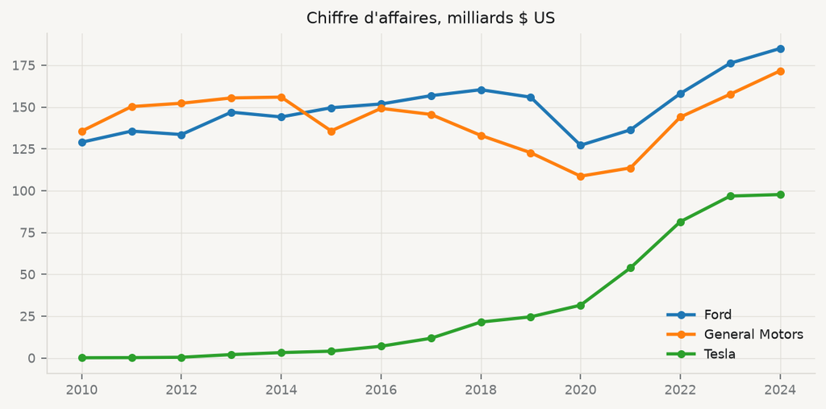

```python
from plotstyle import setup
plt = setup()

auto = entreprises[entreprises["secteur"] == "Automobile"]
fig, ax = plt.subplots()
for nom, groupe in auto.groupby("entreprise"):
    ax.plot(groupe["annee"], groupe["chiffre_affaires"] / 1000,
            marker="o", label=nom)
ax.set_title("Chiffre d'affaires, milliards $ US")
ax.legend(frameon=False)
plt.show()
```

## Ce que le graphique montre, et ce qu’il ne montre pas

| Il montre | Il ne montre pas |
| --- | --- |
| La croissance de Tesla depuis 2018 | Les émissions de ces véhicules |
| Le creux de 2020 chez Ford et GM | La part de véhicules électriques dans les ventes de Ford et GM |
| Que Tesla reste plus petite en ventes | Si Tesla est « bonne pour l’environnement » |

Pour la question environnementale, il faudra **d’autres données** : les émissions de CO₂ par pays (Our World in Data), le mix électrique, les ventes de véhicules électriques. Les importer est l’objet de la séance 3.

# L’IA générative dans ce cours

## Un partenaire d’étude, pas un corrigé

| Utilisez-la pour | Ne l’utilisez pas pour |
| --- | --- |
| **Expliquer** un message d’erreur | Produire un résultat que vous ne savez pas vérifier |
| **Commenter** votre code ligne par ligne | Inventer des chiffres ou des références |
| Vous **interroger** sur un concept | Écrire votre rapport à votre place |
| Proposer **une autre façon** d’écrire un calcul | Choisir vos données sans regarder la source |

> **Règle permanente du cours.** Chaque fois que l’IA intervient dans un travail remis, vous indiquez ce que vous lui avez demandé et **ce que vous avez vérifié, et comment**. Une affirmation non vérifiée d’un modèle de langage a la valeur d’une affirmation non vérifiée d’un inconnu.

## Trois requêtes qui fonctionnent

- « Voici mon message d’erreur et les cinq lignes qui le précèdent. **Explique** ce qu’il veut dire, sans me donner le code corrigé. »
- « Explique-moi ce que fait chaque ligne de ce code pandas, comme à quelqu’un qui débute. »
- « Pose-moi cinq questions pour vérifier que j’ai compris ce qu’est un DataFrame. »

Une IA écrit volontiers `df.append(...)` : cette méthode **n’existe plus** depuis pandas 2.0. Le code généré vise souvent une version ancienne. Exécutez-le, lisez l’erreur, et corrigez.

## Avant la pratique

- Votre `.venv` est **activé** et sélectionné dans VS Code
- `verifier_environnement.py` affiche **OK** partout
- Vous savez où est `data/entreprises.csv`

**Pratique :** *Tesla est-elle plus rentable que Ford — et depuis quand ?*